# IODS course project

# Dimention reduction

## Descriptions on the data

The data is a joined data set of Human Development Index and Gender Development Index that is originated from the United Nations Development Programme’s website. Source of the data: http://hdr.undp.org/en/content/human-development-index-hdi.  
The data has the following variables:

1. hdirank = HDI ranking for countries
2. Country = Country name
3. hdi = Human Development Index (HDI)
4. lifeexp = Life expectancy at birth
5. expedu = Expected years of schooling
6. meanedu = Mean years of schooling
7. gni = Gross National Income (GNI) per capita
8. gni-hdi = GNI per capita rank minus HDI rank
9. giirank = GII ranking for countries
10. gii = Gender Inequality Index (GII)
11. matmor = Maternal mortality ratio
12. adobirth = Adolescent birth rate
13. repparl = Percetange of female representatives in parliament
14. edu2F = Proportion of females with at least secondary education
15. edu2M = Proportion of males with at least secondary education
16. labfF = Proportion of females in the labour force
17. labfM = Proportion of males in the labour force
18. edu2FM - the ratio of Female and Male populations with secondary education in each country (2eduF / 2eduM)
19. labfFM = the ratio of labour force participation of females and males in each country (labfF / labfM).

```r
data <- read.table("C:/R scripts/IODS-project/data/human.csv")

library(tidyr)
library(dplyr)
library(ggplot2)
library(GGally)
library(corrplot)

summary (data)
```

```
##      edu2FM           labfFM         lifeexp         expeedu
##  Min.   :  2.05   Min.   :40.90   Min.   :49.00   Min.   : 5.40
##  1st Qu.: 33.27   1st Qu.:56.65   1st Qu.:66.30   1st Qu.:11.25
##  Median : 56.95   Median :63.40   Median :74.20   Median :13.50
##  Mean   : 58.03   Mean   :63.45   Mean   :71.65   Mean   :13.18
##  3rd Qu.: 86.65   3rd Qu.:69.30   3rd Qu.:77.25   3rd Qu.:15.20
##  Max.   :100.00   Max.   :89.15   Max.   :83.50   Max.   :20.20
##       gni             matmor          adobirth         repparl
##  Min.   :   581   Min.   :   1.0   Min.   :  0.60   Min.   : 0.00
##  1st Qu.:  4198   1st Qu.:  11.5   1st Qu.: 12.65   1st Qu.:12.40
##  Median : 12040   Median :  49.0   Median : 33.60   Median :19.30
##  Mean   : 17628   Mean   : 149.1   Mean   : 47.16   Mean   :20.91
##  3rd Qu.: 24512   3rd Qu.: 190.0   3rd Qu.: 71.95   3rd Qu.:27.95
##  Max.   :123124   Max.   :1100.0   Max.   :204.80   Max.   :57.50
```

The variables in the data have different scales. Below we can see some graphic overview of the dataset.  
Correlations:  
1) Positive:  
- lifeexp and edu2FM (r = 0.710), a large correlation shows that in countries with beigger life expectancy at birth there is begger ratio of Female and Male populations with secondary education  
- expeedu and edu2FM (r = 0.778), the correlation shows that the bigger expected years of schooling, the bigger ratio of Female and Male populations with secondary education  
- gni and eduFM (0.542), a moderate correlation shows that in countries with bigger Gross National Income (GNI) per capita there is bigger ratio of Female and Male populations with secondary education  
- expeedu and lifeexp (r = 0.789), a large correlation shows that in countries with bigger Expected years of schooling, life expectancy at birth is bigger  
- gni and lifeexp (r = 0.627), a moderate correlation shows that in countries that have bigger Gross National Income (GNI) per capita, life expectancy at birth is higher  
- adobirth and matmor (r = 0.759), the large association shows that in countries with higher Adolescent birth rate, Maternal mortality ratio is higher

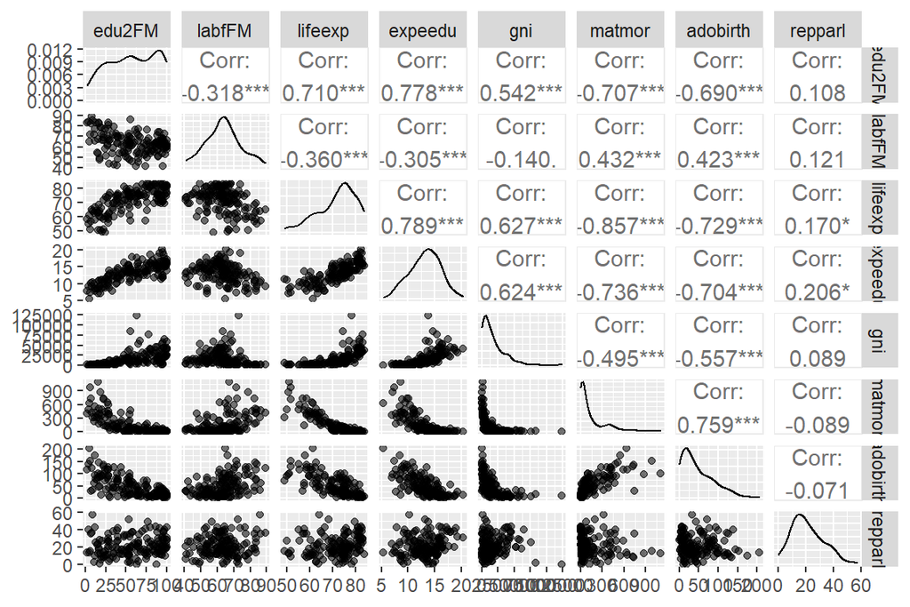

```r
ggpairs(data, mapping = aes(alpha=0.3), lower = list(combo = wrap("facethist", bins = 20)))
```

## Principal component analysis (PCA) Firstly, the PCA is perfomed with not standartizied data.

```r
# perform principal component analysis (with the SVD method)
PCA_1 <- prcomp(data)

s1 <-summary(PCA_1)
s1
```

```
## Importance of components:
##                              PC1      PC2  PC3  PC4   PC5   PC6   PC7   PC8
## Standard deviation     1.854e+04 186.1743 26.2 18.3 11.67 8.657 3.714 1.426
## Proportion of Variance 9.999e-01   0.0001  0.0  0.0  0.00 0.000 0.000 0.000
## Cumulative Proportion  9.999e-01   1.0000  1.0  1.0  1.00 1.000 1.000 1.000
```

```r
PCA_1
```

```
## Standard deviations (1, .., p=8):
## [1] 18544.170799   186.174340    26.202403    18.304196    11.665826
## [6]     8.657387     3.713783     1.425649
##
## Rotation (n x k) = (8 x 8):
##                    PC1          PC2          PC3           PC4           PC5
## edu2FM   -8.571849e-04 -0.080819610 -0.369612023 -0.9224135460  6.059960e-02
## labfFM    7.736650e-05  0.023238470  0.073933350 -0.0414552136 -3.030003e-01
## lifeexp  -2.815825e-04 -0.028243392 -0.016953743 -0.0251331185 -5.720881e-02
## expeedu  -9.562915e-05 -0.007563104 -0.020533695 -0.0339342421 -2.539794e-02
## gni      -9.999828e-01  0.005823107  0.000616372  0.0001796211  6.114001e-05
## matmor    5.655739e-03  0.988078062 -0.148612616 -0.0280034590  9.601322e-04
## adobirth  1.233962e-03  0.125421892  0.913851339 -0.3754232019  4.877079e-02
## repparl  -5.526462e-05 -0.003234070  0.001179486 -0.0626474456 -9.477453e-01
##                    PC6           PC7           PC8
## edu2FM   -1.045561e-02 -0.0320831305  0.0345933498
## labfFM   -9.487597e-01  0.0179161447 -0.0005018860
## lifeexp   3.600044e-02  0.9904926074  0.1124217211
## expeedu   1.039982e-02  0.1094101348 -0.9927969760
## gni       7.975111e-05 -0.0001048564  0.0000207890
## matmor    1.400194e-02  0.0245444218 -0.0006698197
## adobirth  7.531476e-02  0.0104901127 -0.0063270070
## repparl   3.040941e-01 -0.0699358234  0.0218652509
```

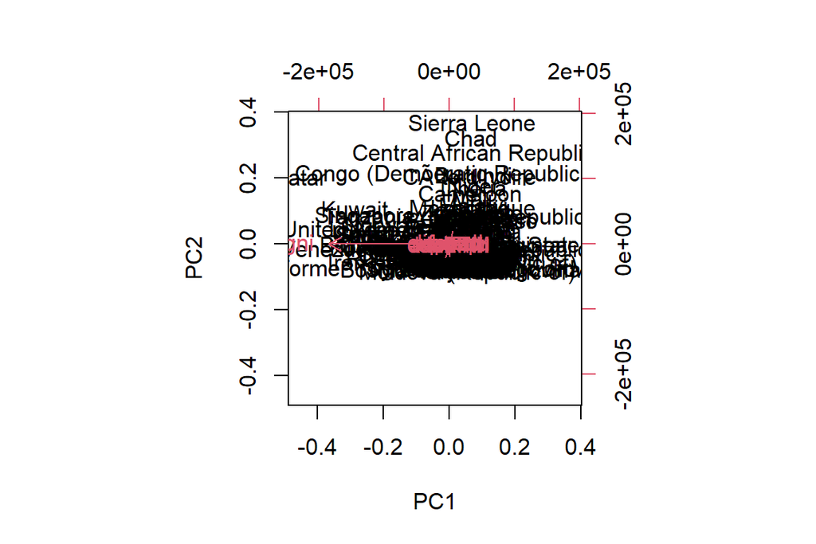

```r
biplot(PCA_1, choices = 1:2)
```

```r
# rounded percentages of variance captured by each PC
var1 <- round(100*s1$importance[2,], digits = 1)

# print out the percentages of variance
var1
```

```
## PC1 PC2 PC3 PC4 PC5 PC6 PC7 PC8
## 100   0   0   0   0   0   0   0
```

The analysis gave to us 8 dimentions, one for each variable. We can see that all the principal components are not correlated. PC1 captures the biggest variance, the every next explain less and less of variabnce. When I round persentages of variance captured by each PC, we can see that the first explains 100% of variance. On the biplot we can see the observations represented by the first two principal components along with arrows representing the original variables.

With a next step, I standartize variables and repeat the above analysis.

```r
# standardize the variables
data_sc <- scale(data)

# perform principal component analysis (with the SVD method)
PCA_2 <- prcomp(data_sc)

s2<- summary(PCA_2)
s2
```

```
## Importance of components:
##                           PC1    PC2     PC3     PC4     PC5     PC6     PC7
## Standard deviation     2.1585 1.0679 0.88106 0.68579 0.59186 0.53987 0.44297
## Proportion of Variance 0.5824 0.1426 0.09703 0.05879 0.04379 0.03643 0.02453
## Cumulative Proportion  0.5824 0.7249 0.82195 0.88074 0.92453 0.96096 0.98549
##                            PC8
## Standard deviation     0.34071
## Proportion of Variance 0.01451
## Cumulative Proportion  1.00000
```

```r
PCA_2
```

```
## Standard deviations (1, .., p=8):
## [1] 2.1584687 1.0678839 0.8810583 0.6857865 0.5918650 0.5398707 0.4429730
## [8] 0.3407058
##
## Rotation (n x k) = (8 x 8):
##                  PC1        PC2          PC3         PC4          PC5
## edu2FM   -0.39556969 0.02510493 -0.078866605  0.31220840 -0.697043736
## labfFM    0.21590149 0.57685573 -0.617756283  0.44769345  0.166725322
## lifeexp  -0.42391815 0.05251511 -0.007929215  0.08631790  0.390722065
## expeedu  -0.41413247 0.13161969 -0.059589507  0.09293514 -0.307479818
## gni      -0.32896485 0.16287028 -0.501208047 -0.74508370  0.020320217
## matmor    0.41397085 0.08372472 -0.098030180 -0.31521159 -0.440093945
## adobirth  0.40088980 0.09519879 -0.017111886 -0.06213506 -0.212104218
## repparl  -0.07346083 0.77712693  0.589432958 -0.16625266 -0.006429306
##                  PC6          PC7         PC8
## edu2FM    0.03784034 -0.496212213  0.07531214
## labfFM    0.10289515  0.009021408 -0.01027783
## lifeexp  -0.38373845 -0.074142959  0.71035611
## expeedu  -0.21625478  0.799985095 -0.13302852
## gni      -0.02434938 -0.174234770 -0.16592957
## matmor    0.20363260  0.224416684  0.65355817
## adobirth -0.86396208 -0.138030767 -0.12489920
## repparl   0.07395789 -0.091900097 -0.04061224
```

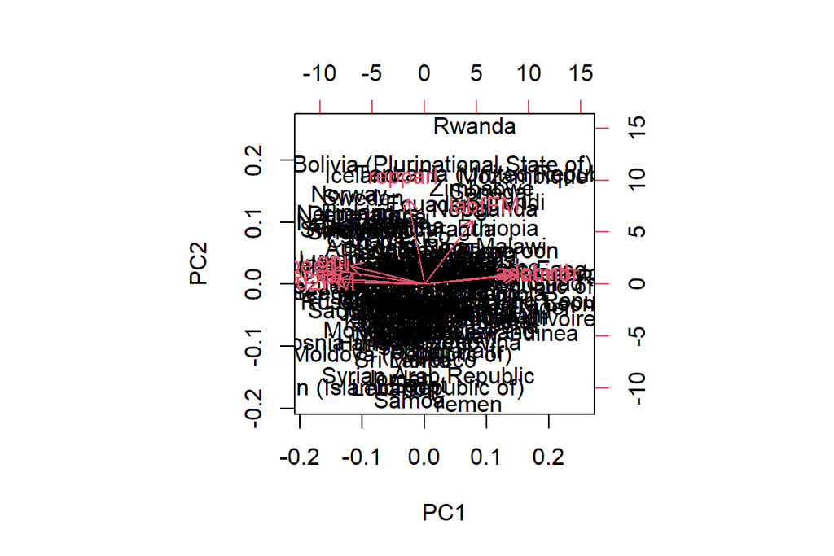

```r
biplot(PCA_2, choices = 1:2)
```

```r
# rounded percentages of variance captured by each PC
var2 <- round(100*s2$importance[2,], digits = 1)

# print out the percentages of variance
var2
```

```
##  PC1  PC2  PC3  PC4  PC5  PC6  PC7  PC8
## 58.2 14.3  9.7  5.9  4.4  3.6  2.5  1.5
```

There are few observations that I can make looking at the distribution of the countries: the rich and developed countries with good representation of men and wemen are lokated on the upper left corned (countries such as Norvay, Iceland and so on); on the lower left corner there are rich and developed countries that, however have some issues with representation of women in parliament of work places (countries like Saudi Arabia). On the right side there are countries that are less wealty: on the upper right poor countries with good women representation (Burundi); on the lower right there are poor countries with issues in women representation (Niger, Afganistan).

## Tea dataset

```r
library(FactoMineR)
data(tea)
str(tea)
```

```
## 'data.frame':    300 obs. of  36 variables:
##  $ breakfast       : Factor w/ 2 levels "breakfast","Not.breakfast": 1 1 2 2 1 2 1 2 1 1 ...
##  $ tea.time        : Factor w/ 2 levels "Not.tea time",..: 1 1 2 1 1 1 2 2 2 1 ...
##  $ evening         : Factor w/ 2 levels "evening","Not.evening": 2 2 1 2 1 2 2 1 2 1 ...
##  $ lunch           : Factor w/ 2 levels "lunch","Not.lunch": 2 2 2 2 2 2 2 2 2 2 ...
##  $ dinner          : Factor w/ 2 levels "dinner","Not.dinner": 2 2 1 1 2 1 2 2 2 2 ...
##  $ always          : Factor w/ 2 levels "always","Not.always": 2 2 2 2 1 2 2 2 2 2 ...
##  $ home            : Factor w/ 2 levels "home","Not.home": 1 1 1 1 1 1 1 1 1 1 ...
##  $ work            : Factor w/ 2 levels "Not.work","work": 1 1 2 1 1 1 1 1 1 1 ...
##  $ tearoom         : Factor w/ 2 levels "Not.tearoom",..: 1 1 1 1 1 1 1 1 1 2 ...
##  $ friends         : Factor w/ 2 levels "friends","Not.friends": 2 2 1 2 2 2 1 2 2 2 ...
##  $ resto           : Factor w/ 2 levels "Not.resto","resto": 1 1 2 1 1 1 1 1 1 1 ...
##  $ pub             : Factor w/ 2 levels "Not.pub","pub": 1 1 1 1 1 1 1 1 1 1 ...
##  $ Tea             : Factor w/ 3 levels "black","Earl Grey",..: 1 1 2 2 2 2 2 1 2 1 ...
##  $ How             : Factor w/ 4 levels "alone","lemon",..: 1 3 1 1 1 1 1 3 3 1 ...
```

[output cut: 22 more lines]

```r
dim(tea)
```

```
## [1] 300  36
```

```r
# data has 300 obs and 36 var
```

The data describes preferences of people onto how to drink tea. There are categorical and dichotomous variables, age is continious and categorical. There are data has 300 observations and 36 variables.

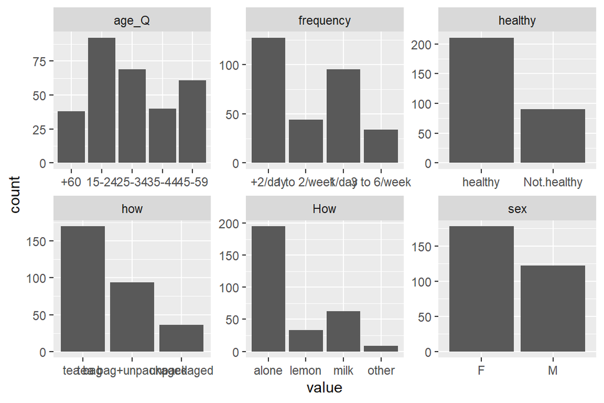

```r
keep <- c("age_Q", "sex", "How", "how", "frequency", "healthy")
tea <- dplyr::select(tea, one_of(keep))
gather(tea) %>% ggplot(aes(value)) + facet_wrap("key", scales = "free") + geom_bar()
```

Next, I will do multiple correspondence analysis and visualize it

```r
# multiple correspondence analysis
MCA <- MCA(tea, graph = FALSE)

# summary of the model
summary(MCA)
```

```
##
## Call:
## MCA(X = tea, graph = FALSE)
##
##
## Eigenvalues
##                        Dim.1   Dim.2   Dim.3   Dim.4   Dim.5   Dim.6   Dim.7
## Variance               0.244   0.224   0.212   0.198   0.191   0.178   0.173
## % of var.             10.440   9.599   9.077   8.493   8.183   7.612   7.396
## Cumulative % of var.  10.440  20.039  29.117  37.610  45.793  53.404  60.801
##                        Dim.8   Dim.9  Dim.10  Dim.11  Dim.12  Dim.13  Dim.14
## Variance               0.160   0.156   0.145   0.127   0.116   0.110   0.101
## % of var.              6.846   6.666   6.199   5.464   4.952   4.731   4.340
## Cumulative % of var.  67.647  74.313  80.512  85.976  90.928  95.660 100.000
##
## Individuals (the 10 first)
##          Dim.1    ctr   cos2    Dim.2    ctr   cos2    Dim.3    ctr   cos2
## 1     |  0.181  0.045  0.017 |  0.453  0.305  0.104 | -0.383  0.231  0.074 |
## 2     | -0.241  0.079  0.030 |  0.607  0.548  0.189 | -0.695  0.760  0.247 |
## 3     | -0.504  0.348  0.198 | -0.051  0.004  0.002 | -0.020  0.001  0.000 |
## 4     |  0.119  0.020  0.011 |  0.068  0.007  0.004 | -0.619  0.604  0.302 |
## 5     |  0.245  0.082  0.035 | -0.118  0.021  0.008 | -0.046  0.003  0.001 |
## 6     |  0.119  0.020  0.011 |  0.068  0.007  0.004 | -0.619  0.604  0.302 |
## 7     |  0.263  0.095  0.024 |  0.030  0.001  0.000 |  0.267  0.113  0.025 |
## 8     | -0.128  0.023  0.006 |  0.228  0.077  0.017 | -0.546  0.470  0.100 |
## 9     |  0.152  0.032  0.008 |  0.099  0.015  0.003 | -0.069  0.007  0.002 |
## 10    | -0.147  0.030  0.010 |  0.031  0.001  0.000 |  0.232  0.085  0.026 |
##
## Categories (the 10 first)
##           Dim.1     ctr    cos2  v.test     Dim.2     ctr    cos2  v.test
## 15-24 |  -0.369   2.851   0.060  -4.240 |  -0.878  17.597   0.341 -10.098 |
## 25-34 |   1.045  17.198   0.326   9.880 |   0.186   0.589   0.010   1.753 |
## 35-44 |  -0.186   0.315   0.005  -1.260 |   0.215   0.458   0.007   1.457 |
## 45-59 |  -0.104   0.150   0.003  -0.906 |   0.271   1.110   0.019   2.366 |
## +60   |  -0.644   3.591   0.060  -4.239 |   1.128  12.000   0.185   7.430 |
## F     |  -0.519  10.924   0.393 -10.835 |  -0.310   4.255   0.141  -6.484 |
## M     |   0.757  15.938   0.393  10.835 |   0.453   6.208   0.141   6.484 |
## alone |   0.057   0.142   0.006   1.332 |  -0.409   8.099   0.311  -9.642 |
## lemon |   0.273   0.561   0.009   1.660 |   0.519   2.207   0.033   3.156 |
## milk  |   0.000   0.000   0.000   0.001 |   0.735   8.448   0.144   6.555 |
##         Dim.3     ctr    cos2  v.test
## 15-24  -0.546   7.199   0.132  -6.281 |
## 25-34   0.148   0.394   0.007   1.395 |
## 35-44   0.106   0.117   0.002   0.716 |
## 45-59   0.005   0.000   0.000   0.046 |
## +60     0.935   8.709   0.127   6.156 |
## F       0.049   0.114   0.004   1.032 |
## M      -0.072   0.166   0.004  -1.032 |
## alone   0.052   0.137   0.005   1.219 |
## lemon   0.934   7.550   0.108   5.677 |
## milk   -0.830  11.397   0.183  -7.404 |
##
## Categorical variables (eta2)
##             Dim.1 Dim.2 Dim.3
## age_Q     | 0.352 0.427 0.209 |
## sex       | 0.393 0.141 0.004 |
## How       | 0.159 0.351 0.291 |
## how       | 0.113 0.048 0.421 |
## frequency | 0.258 0.187 0.346 |
## healthy   | 0.187 0.191 0.001 |
```

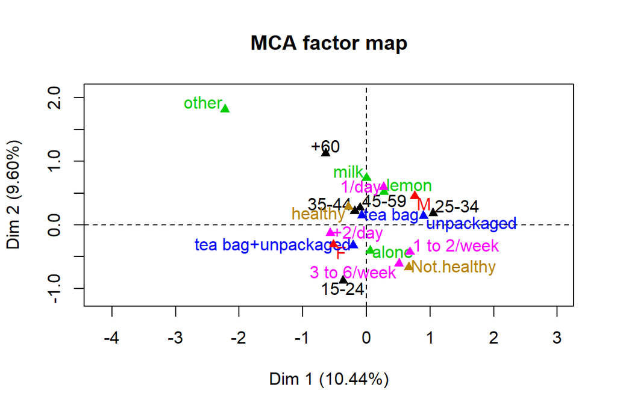

```r
# visualize MCA
plot(MCA, invisible=c("ind"), habillage = "quali", graph.type = "classic")
```

All the dimensions explain quite equal amount of variation. To explain 50% of variation we will need 6 dimensions. We are suggested to have 3 dimensions, where the first one would explain sex; second - age_Q, How; third - how, frequency; healthy is almost equaly explained by first and second clusters. Therefore, we can say that if people dring tea alone or with milk or lemon, it is correlated to age; frequency is correlated to the way people make tea (bag or not).  
The distance between the categories tells us how similar they are. Therefore, 25-34 y.o. people prefer unpackged tea 1 tim per day. The majority of 25-35 people t=whoo are drinking tea are males. Females prefer to drink tea 2 times per day and more likely to drink tea made of tea bag. People from 35 to 44 and from 45 to 59 tend to drink bag tea and believe that it is healthy to drink tea. The older people the more they tend to drink tea with lemon or milk. Also, old peopel are more likely to believe that to drink tea is healthy. Category “other” is obvious outliner.

# Ex 6. Analysis of longitudinal data

## RATS data analysis

The data for this analysis consists of weight observations over 64 days of rats separatet for three groups.

```r
library(dplyr)
library(tidyr)
library(ggplot2)
```

Firstly, we will implement the analyses of Chapter 8 of MABS using the RATS data.

```r
# read the RATS data
# load the data (saved in long form)
rats_long <- read.table("C:/R scripts/IODS-project/data/rats_long.txt", header = TRUE)

#wide format data
rats <- read.table("https://raw.githubusercontent.com/KimmoVehkalahti/MABS/master/Examples/data/rats.txt", sep = "\t", header = T)

str(rats_long)
```

```
## 'data.frame':    176 obs. of  5 variables:
##  $ ID         : int  1 2 3 4 5 6 7 8 9 10 ...
##  $ Group      : int  1 1 1 1 1 1 1 1 2 2 ...
##  $ WD         : chr  "WD1" "WD1" "WD1" "WD1" ...
##  $ measurement: int  240 225 245 260 255 260 275 245 410 405 ...
##  $ Time       : int  1 1 1 1 1 1 1 1 1 1 ...
```

```r
str(rats)
```

```
## 'data.frame':    16 obs. of  13 variables:
##  $ ID   : int  1 2 3 4 5 6 7 8 9 10 ...
##  $ Group: int  1 1 1 1 1 1 1 1 2 2 ...
##  $ WD1  : int  240 225 245 260 255 260 275 245 410 405 ...
##  $ WD8  : int  250 230 250 255 260 265 275 255 415 420 ...
##  $ WD15 : int  255 230 250 255 255 270 260 260 425 430 ...
##  $ WD22 : int  260 232 255 265 270 275 270 268 428 440 ...
##  $ WD29 : int  262 240 262 265 270 275 273 270 438 448 ...
##  $ WD36 : int  258 240 265 268 273 277 274 265 443 460 ...
##  $ WD43 : int  266 243 267 270 274 278 276 265 442 458 ...
##  $ WD44 : int  266 244 267 272 273 278 271 267 446 464 ...
##  $ WD50 : int  265 238 264 274 276 284 282 273 456 475 ...
##  $ WD57 : int  272 247 268 273 278 279 281 274 468 484 ...
##  $ WD64 : int  278 245 269 275 280 281 284 278 478 496 ...
```

```r
# making factors out of ID and Group variables
rats_long$ID <- factor(rats_long$ID)
rats_long$Group <- factor(rats_long$Group)

str(rats_long) #done!
```

```
## 'data.frame':    176 obs. of  5 variables:
##  $ ID         : Factor w/ 16 levels "1","2","3","4",..: 1 2 3 4 5 6 7 8 9 10 ...
##  $ Group      : Factor w/ 3 levels "1","2","3": 1 1 1 1 1 1 1 1 2 2 ...
##  $ WD         : chr  "WD1" "WD1" "WD1" "WD1" ...
##  $ measurement: int  240 225 245 260 255 260 275 245 410 405 ...
##  $ Time       : int  1 1 1 1 1 1 1 1 1 1 ...
```

```r
# summary of the variables
summary(rats_long)
```

```
##        ID      Group       WD             measurement         Time
##  1      : 11   1:88   Length:176         Min.   :225.0   Min.   : 1.00
##  2      : 11   2:44   Class :character   1st Qu.:267.0   1st Qu.:15.00
##  3      : 11   3:44   Mode  :character   Median :344.5   Median :36.00
##  4      : 11                             Mean   :384.5   Mean   :33.55
##  5      : 11                             3rd Qu.:511.2   3rd Qu.:50.00
##  6      : 11                             Max.   :628.0   Max.   :64.00
##  (Other):110
```

To begin we shall plot the rats values for all rats, differentiating between the groups into which the rats have been randomized.

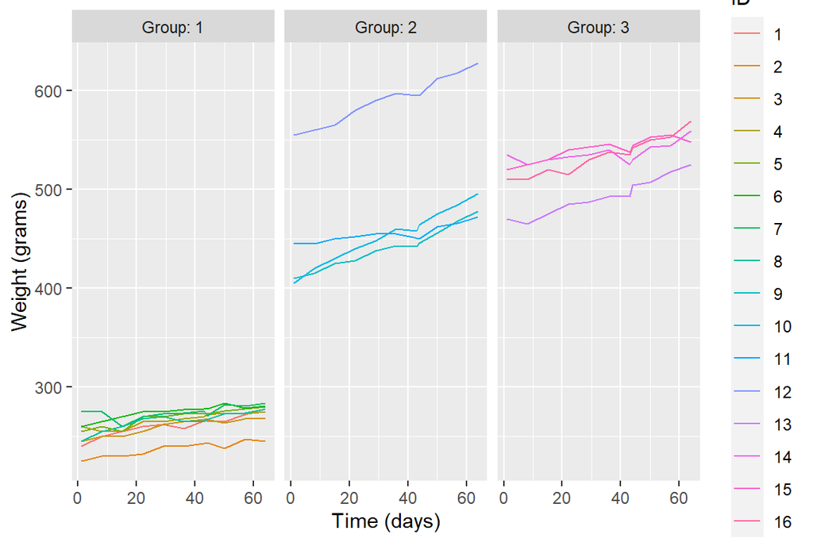

```r
ggplot(rats_long, aes(x = Time, y = measurement, col=ID)) +
  geom_line() +
  facet_grid(. ~ Group, labeller = label_both) +
  scale_x_continuous(name = "Time (days)")+
  scale_y_continuous(name = "Weight (grams)")
```

We want to observe how rats that had big wheit from the beggining end to have higher weight throughout the study. This phenomenon is generally referred to as tracking.

The tracking phenomenon can be seen more clearly in a plot of the standardized values of each observation.

```r
# Standardize the scores
rats_long <- rats_long %>%
  group_by(Time) %>%
  mutate( stdrats = (measurement - mean(measurement))/sd(measurement) ) %>%
  ungroup()
glimpse(rats_long)
```

```
## Rows: 176
## Columns: 6
## $ ID          <fct> 1, 2, 3, 4, 5, 6, 7, 8, 9, 10, 11, 12, 13, 14, 15, 16, 1, ~
## $ Group       <fct> 1, 1, 1, 1, 1, 1, 1, 1, 2, 2, 2, 2, 3, 3, 3, 3, 1, 1, 1, 1~
## $ WD          <chr> "WD1", "WD1", "WD1", "WD1", "WD1", "WD1", "WD1", "WD1", "W~
## $ measurement <int> 240, 225, 245, 260, 255, 260, 275, 245, 410, 405, 445, 555~
## $ Time        <int> 1, 1, 1, 1, 1, 1, 1, 1, 1, 1, 1, 1, 1, 1, 1, 1, 8, 8, 8, 8~
## $ stdrats     <dbl> -1.0011429, -1.1203857, -0.9613953, -0.8421525, -0.8819001~
```

Making a plot using standartizied values.

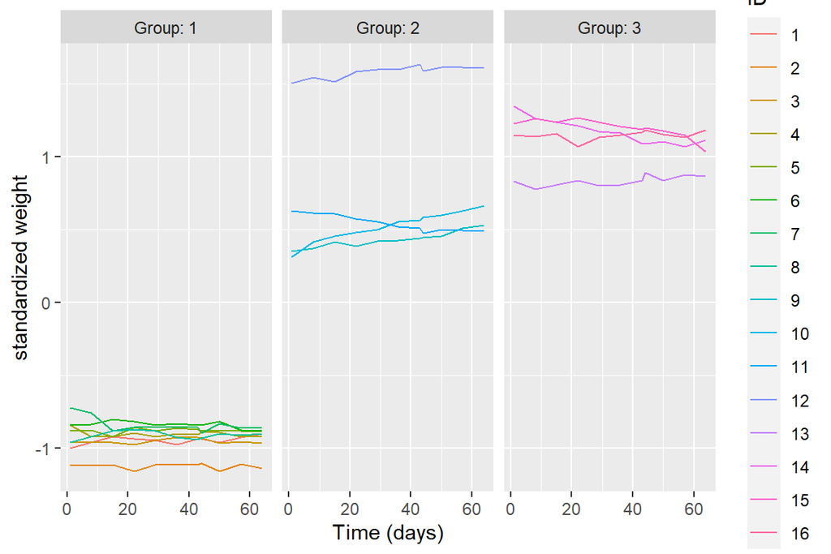

```r
ggplot(rats_long, aes(x = Time, y = stdrats, col=ID)) +
  geom_line() +
  facet_grid(. ~ Group, labeller = label_both) +
  scale_x_continuous(name = "Time (days)")+
  scale_y_continuous(name = "standardized weight")
```

Now we can see that trend of the observations is not clear anymore while before we could clearely see the trend for growth.

Next, we will produce graphs showing average (mean) profiles for each treatment group along with some indication of the variation of the observations at each time point, in this case the standard error of mean.

```r
# number of days, baseline (day 1) included
n <- 20
# summary data with mean and standard error of measurement by Group and time
summ_rats <- rats_long %>%
  group_by(Group, Time) %>%
  summarise( mean = mean(measurement), se = sd(measurement)/sqrt(n) ) %>%
  ungroup()
glimpse(summ_rats)
```

```
## Rows: 33
## Columns: 4
## $ Group <fct> 1, 1, 1, 1, 1, 1, 1, 1, 1, 1, 1, 2, 2, 2, 2, 2, 2, 2, 2, 2, 2, 2~
## $ Time  <int> 1, 8, 15, 22, 29, 36, 43, 44, 50, 57, 64, 1, 8, 15, 22, 29, 36, ~
## $ mean  <dbl> 250.625, 255.000, 254.375, 261.875, 264.625, 265.000, 267.375, 2~
## $ se    <dbl> 3.403648, 2.927700, 2.566091, 3.041234, 2.472528, 2.634930, 2.44~
```

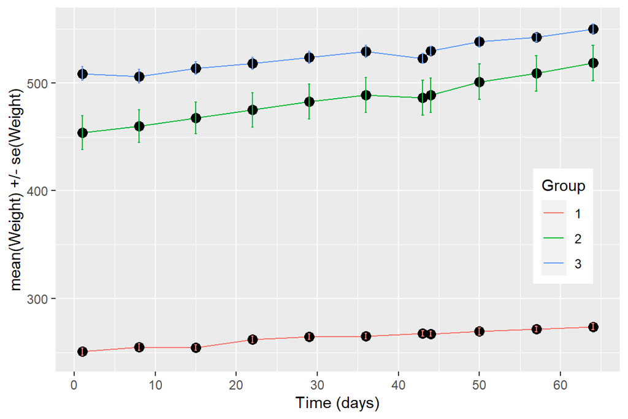

```r
# plotting the mean profiles with errorbars
ggplot(summ_rats, aes(x = Time, y = mean)) +
  geom_line(aes(col=Group)) +
  geom_point(size=3) +
  scale_shape_manual(values = c(1,2,3)) +
  geom_errorbar(aes(ymin=mean-se, ymax=mean+se, col = Group), width=0.3) +
  theme(legend.position = c(0.9,0.4)) +
  scale_x_continuous(name = "Time (days)", breaks = seq(0, 60, 10)) +
  scale_y_continuous(name = "mean(Weight) +/- se(Weight)")
```

```r
# I changed the plot that was given on DataCamp out of curiosity and I ended up thinking that color representation of the groups is prettier :)
```

Observations from the group 2 have the biggest standart error possibly due to the otliner that was mentioned above. On the plot we can note the growth tendency in aoll the groups. It seems like rats from the first group had the smallest increase in weight in average. Observations from groups 2 and 3 have quite similar pattern of inrease and decrese. I suppose the outliner is affecting the average of the 2nd group.

Next, we look into differencies between groups and producing boxplots of the mean values of each group.

```r
# creating a summary data by Group and ID with mean as the summary variable (excluding the baseline)
gr_summ_rats <- rats_long %>%
  filter(Time > 1) %>%
  group_by(Group, ID) %>%
  summarise( mean=mean(measurement) ) %>%
  ungroup()
str(gr_summ_rats)
```

```
## tibble [16 x 3] (S3: tbl_df/tbl/data.frame)
##  $ Group: Factor w/ 3 levels "1","2","3": 1 1 1 1 1 1 1 1 2 2 ...
##  $ ID   : Factor w/ 16 levels "1","2","3","4",..: 1 2 3 4 5 6 7 8 9 10 ...
##  $ mean : num [1:16] 263 239 262 267 271 ...
```

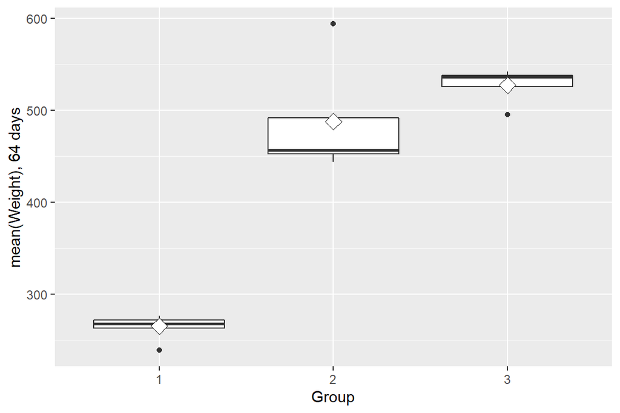

```r
# draw a boxplot of the mean versus Group
ggplot(gr_summ_rats, aes(x = Group, y = mean)) +
  geom_boxplot() +
  stat_summary(fun.y = "mean", geom = "point", shape=23, size=4, fill = "white") +
  scale_y_continuous(name = "mean(Weight), 64 days")
```

As expected, we can see that one there is an otliner in the froup 2 since the variation is big and the distribution is notably skewed. The outliner must be higher than average.

We will drop the outliner and vizualize the boxplot again.

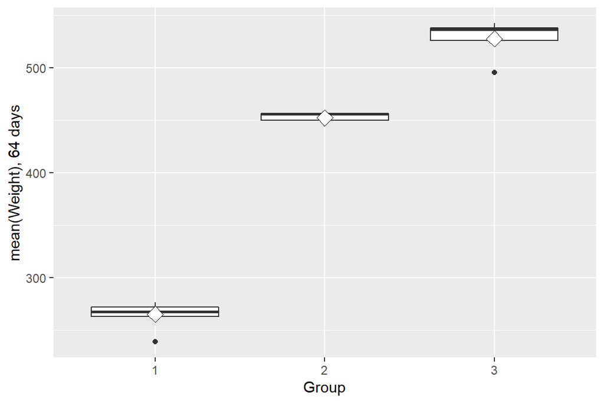

```r
# create a new data by filtering the outlier and adjust the ggplot code the draw the plot again with the new data
gr_summ_rats.nooutl <- gr_summ_rats %>% filter(mean < 570)

ggplot(gr_summ_rats.nooutl, aes(x = Group, y = mean)) +
  geom_boxplot() +
  stat_summary(fun.y = "mean", geom = "point", shape=23, size=4, fill = "white") +
  scale_y_continuous(name = "mean(Weight), 64 days")
```

```r
# add the baseline from the original data as a new variable to the summary data
gr_summ_rats1 <- gr_summ_rats %>%
  mutate(baseline = rats$WD1)

# fit the linear model with the mean as the response
model <- lm(mean ~ baseline + Group, data = gr_summ_rats1)
model
```

```
##
## Call:
## lm(formula = mean ~ baseline + Group, data = gr_summ_rats1)
##
## Coefficients:
## (Intercept)     baseline       Group2       Group3
##     33.1637       0.9251      34.8575      23.6753
```

```r
# compute the analysis of variance table for the fitted model with anova()
anova(model)
```

```
## Analysis of Variance Table
##
## Response: mean
##           Df Sum Sq Mean Sq   F value   Pr(>F)
## baseline   1 253625  253625 1859.8201 1.57e-14 ***
## Group      2    879     439    3.2219  0.07586 .
## Residuals 12   1636     136
## ---
## Signif. codes:  0 '***' 0.001 '**' 0.01 '*' 0.05 '.' 0.1 ' ' 1
```

Analysis showed that there is no evidence of a group difference.

## BPRS data analysis

The BPRS data, in which 40 male subjects were randomly assigned to one of two treatment groups and each subject was rated on the brief psychiatric rating scale (BPRS) measured before treatment began (week 0) and then at weekly intervals for eight weeks. The BPRS assesses the level of 18 symptom constructs such as hostility, suspiciousness, hallucinations and grandiosity; each of these is rated from one (not present) to seven (extremely severe). The scale is used to evaluate patients suspected of having schizophrenia.

```r
# load the data (saved in long form)
bprs_long <- read.table("C:/R scripts/IODS-project/data/bprs_long.txt", header = TRUE)

#checking the data structure
str(bprs_long)
```

```
## 'data.frame':    360 obs. of  5 variables:
##  $ treatment: int  1 1 1 1 1 1 1 1 1 1 ...
##  $ subject  : int  1 2 3 4 5 6 7 8 9 10 ...
##  $ weeks    : chr  "week0" "week0" "week0" "week0" ...
##  $ bprs     : int  42 58 54 55 72 48 71 30 41 57 ...
##  $ week     : int  0 0 0 0 0 0 0 0 0 0 ...
```

```r
# making factors out of treatment and subject variables
bprs_long$treatment <- factor(bprs_long$treatment)
bprs_long$subject <- factor(bprs_long$subject)

# summaries of the variables
summary(bprs_long)
```

```
##  treatment    subject       weeks                bprs            week
##  1:180     1      : 18   Length:360         Min.   :18.00   Min.   :0
##  2:180     2      : 18   Class :character   1st Qu.:27.00   1st Qu.:2
##            3      : 18   Mode  :character   Median :35.00   Median :4
##            4      : 18                      Mean   :37.66   Mean   :4
##            5      : 18                      3rd Qu.:43.00   3rd Qu.:6
##            6      : 18                      Max.   :95.00   Max.   :8
##            (Other):252
```

```r
str(bprs_long) #data has the right form for the continuation of the analysis
```

```
## 'data.frame':    360 obs. of  5 variables:
##  $ treatment: Factor w/ 2 levels "1","2": 1 1 1 1 1 1 1 1 1 1 ...
##  $ subject  : Factor w/ 20 levels "1","2","3","4",..: 1 2 3 4 5 6 7 8 9 10 ...
##  $ weeks    : chr  "week0" "week0" "week0" "week0" ...
##  $ bprs     : int  42 58 54 55 72 48 71 30 41 57 ...
##  $ week     : int  0 0 0 0 0 0 0 0 0 0 ...
```

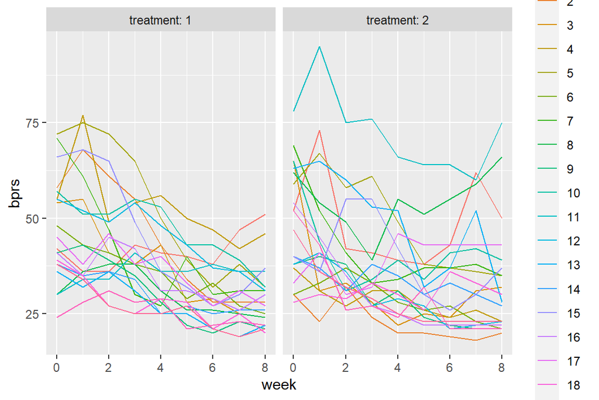

```r
# graph showing all the data
ggplot(bprs_long, aes(x = week, y = bprs, col = subject)) +
  geom_line() +
  facet_grid(. ~ treatment, labeller = label_both) +
  scale_y_continuous(limits = c(min(bprs_long$bprs), max(bprs_long$bprs)))
```

We can see that the differences bettween the observations are big and there is not clear average trend. Roughly, we can recognize some decrese pattern here. One probable pattern is that bprs goes down untill week 5 ot 6 and then go up.

Next, e will plot the data, identifying the observations in each tretment group but ignoring the longitudinal nature of the data.

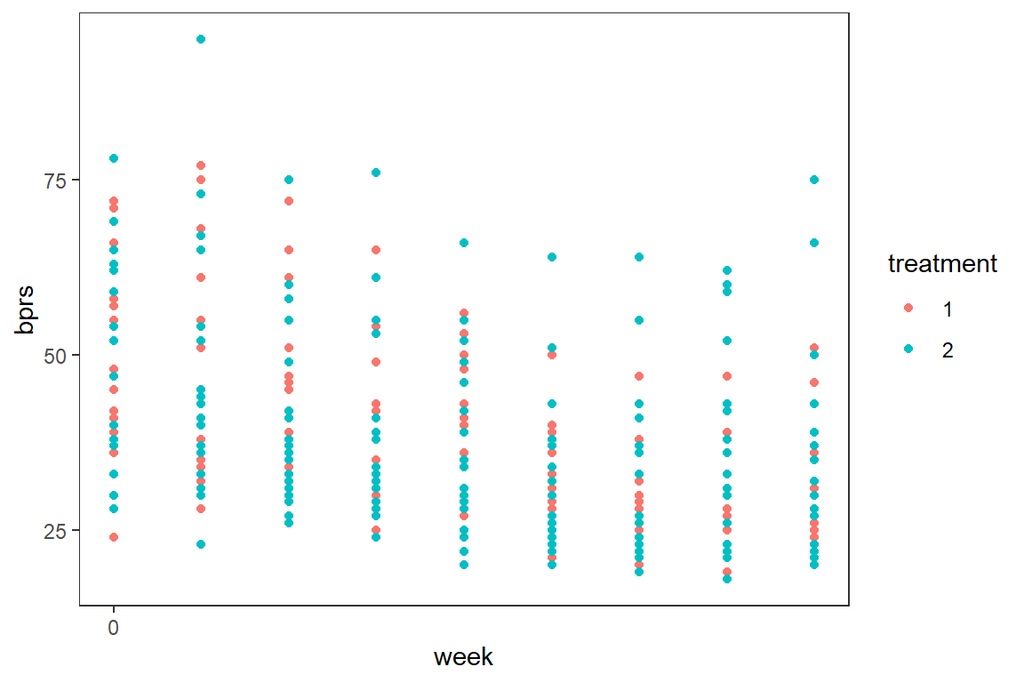

```r
ggplot(bprs_long, aes(x = week, y = bprs, group = subject))+ geom_point(aes(col = treatment))+  scale_x_continuous(name = "week", breaks = seq(0, 60, 10)) + scale_y_continuous(name = "bprs") + theme_bw()+ theme(panel.grid.major = element_blank(), panel.grid.minor = element_blank())
```

```r
# create a regression model2
model2 <- lm(bprs ~ week + treatment, data = bprs_long)
model2
```

```
##
## Call:
## lm(formula = bprs ~ week + treatment, data = bprs_long)
##
## Coefficients:
## (Intercept)         week   treatment2
##     46.4539      -2.2704       0.5722
```

```r
# print out a summary of the model
summary(model2)
```

```
##
## Call:
## lm(formula = bprs ~ week + treatment, data = bprs_long)
##
## Residuals:
##     Min      1Q  Median      3Q     Max
## -22.454  -8.965  -3.196   7.002  50.244
##
## Coefficients:
##             Estimate Std. Error t value Pr(>|t|)
## (Intercept)  46.4539     1.3670  33.982   <2e-16 ***
## week         -2.2704     0.2524  -8.995   <2e-16 ***
## treatment2    0.5722     1.3034   0.439    0.661
## ---
## Signif. codes:  0 '***' 0.001 '**' 0.01 '*' 0.05 '.' 0.1 ' ' 1
##
## Residual standard error: 12.37 on 357 degrees of freedom
## Multiple R-squared:  0.1851, Adjusted R-squared:  0.1806
## F-statistic: 40.55 on 2 and 357 DF,  p-value: < 2.2e-16
```

Here, treatment 2 doesn`t give a significnat difference (p=0.661).

```r
library(lme4)
# Create a random intercept model
int_model <- lmer(bprs ~ week + treatment + (1 | subject), data = bprs_long, REML = FALSE)

# Print the summary of the model
summary(int_model)
```

```
## Linear mixed model fit by maximum likelihood  ['lmerMod']
## Formula: bprs ~ week + treatment + (1 | subject)
##    Data: bprs_long
##
##      AIC      BIC   logLik deviance df.resid
##   2748.7   2768.1  -1369.4   2738.7      355
##
## Scaled residuals:
##     Min      1Q  Median      3Q     Max
## -3.0481 -0.6749 -0.1361  0.4813  3.4855
##
## Random effects:
##  Groups   Name        Variance Std.Dev.
##  subject  (Intercept)  47.41    6.885
##  Residual             104.21   10.208
## Number of obs: 360, groups:  subject, 20
##
## Fixed effects:
##             Estimate Std. Error t value
## (Intercept)  46.4539     1.9090  24.334
## week         -2.2704     0.2084 -10.896
## treatment2    0.5722     1.0761   0.532
##
## Correlation of Fixed Effects:
##            (Intr) week
## week       -0.437
## treatment2 -0.282  0.000
```

```r
# create a random intercept and random slope model
int_slope_model <- lmer(bprs ~ week + treatment + (week | subject), data = bprs_long, REML = FALSE)
int_slope_model
```

```
## Linear mixed model fit by maximum likelihood  ['lmerMod']
## Formula: bprs ~ week + treatment + (week | subject)
##    Data: bprs_long
##       AIC       BIC    logLik  deviance  df.resid
##  2745.440  2772.643 -1365.720  2731.440       353
## Random effects:
##  Groups   Name        Std.Dev. Corr
##  subject  (Intercept) 8.0512
##           week        0.9802   -0.51
##  Residual             9.8707
## Number of obs: 360, groups:  subject, 20
## Fixed Effects:
## (Intercept)         week   treatment2
##     46.4539      -2.2704       0.5722
```

```r
# print a summary of the model
summary(int_slope_model)
```

```
## Linear mixed model fit by maximum likelihood  ['lmerMod']
## Formula: bprs ~ week + treatment + (week | subject)
##    Data: bprs_long
##
##      AIC      BIC   logLik deviance df.resid
##   2745.4   2772.6  -1365.7   2731.4      353
##
## Scaled residuals:
##     Min      1Q  Median      3Q     Max
## -2.8919 -0.6194 -0.0691  0.5531  3.7976
##
## Random effects:
##  Groups   Name        Variance Std.Dev. Corr
##  subject  (Intercept) 64.8222  8.0512
##           week         0.9609  0.9802   -0.51
##  Residual             97.4305  9.8707
## Number of obs: 360, groups:  subject, 20
##
## Fixed effects:
##             Estimate Std. Error t value
## (Intercept)  46.4539     2.1052  22.066
## week         -2.2704     0.2977  -7.626
## treatment2    0.5722     1.0405   0.550
##
## Correlation of Fixed Effects:
##            (Intr) week
## week       -0.582
## treatment2 -0.247  0.000
```

```r
# perform an ANOVA test on the two models
anova(int_model, int_slope_model)
```

```
## Data: bprs_long
## Models:
## int_model: bprs ~ week + treatment + (1 | subject)
## int_slope_model: bprs ~ week + treatment + (week | subject)
##                 npar    AIC    BIC  logLik deviance  Chisq Df Pr(>Chisq)
## int_model          5 2748.7 2768.1 -1369.4   2738.7
## int_slope_model    7 2745.4 2772.6 -1365.7   2731.4 7.2721  2    0.02636 *
## ---
## Signif. codes:  0 '***' 0.001 '**' 0.01 '*' 0.05 '.' 0.1 ' ' 1
```

We can see that the random intercept and random slope model is a better fit for the data (p = 0.02) even though the significnace is quite close to the cut off.

```r
# create a random intercept and random slope model with the interaction
final_model <- lmer(bprs ~ week * treatment + (week | treatment), data = bprs_long, REML = FALSE)
final_model
```

```
## Linear mixed model fit by maximum likelihood  ['lmerMod']
## Formula: bprs ~ week * treatment + (week | treatment)
##    Data: bprs_long
##       AIC       BIC    logLik  deviance  df.resid
##  2843.303  2874.392 -1413.652  2827.303       352
## Random effects:
##  Groups    Name        Std.Dev.  Corr
##  treatment (Intercept) 5.071e-04
##            week        7.948e-05 -1.00
##  Residual              1.228e+01
## Number of obs: 360, groups:  treatment, 2
## Fixed Effects:
##     (Intercept)             week       treatment2  week:treatment2
##         47.8856          -2.6283          -2.2911           0.7158
## optimizer (nloptwrap) convergence code: 0 (OK) ; 0 optimizer warnings; 1 lme4 warnings
```

```r
# print a summary of the model
summary(final_model)
```

```
## Linear mixed model fit by maximum likelihood  ['lmerMod']
## Formula: bprs ~ week * treatment + (week | treatment)
##    Data: bprs_long
##
##      AIC      BIC   logLik deviance df.resid
##   2843.3   2874.4  -1413.7   2827.3      352
##
## Scaled residuals:
##     Min      1Q  Median      3Q     Max
## -1.9453 -0.7547 -0.2281  0.5304  4.1794
##
## Random effects:
##  Groups    Name        Variance  Std.Dev.  Corr
##  treatment (Intercept) 2.571e-07 5.071e-04
##            week        6.318e-09 7.948e-05 -1.00
##  Residual              1.508e+02 1.228e+01
## Number of obs: 360, groups:  treatment, 2
##
## Fixed effects:
##                 Estimate Std. Error t value
## (Intercept)      47.8856     1.6876  28.376
## week             -2.6283     0.3545  -7.415
## treatment2       -2.2911     2.3866  -0.960
## week:treatment2   0.7158     0.5013   1.428
##
## Correlation of Fixed Effects:
##             (Intr) week   trtmn2
## week        -0.840
## treatment2  -0.707  0.594
## wek:trtmnt2  0.594 -0.707 -0.840
## optimizer (nloptwrap) convergence code: 0 (OK)
## boundary (singular) fit: see ?isSingular
```

```r
# perform an ANOVA test on the two models - with interaction and without
anova(final_model, int_slope_model)
```

```
## Data: bprs_long
## Models:
## int_slope_model: bprs ~ week + treatment + (week | subject)
## final_model: bprs ~ week * treatment + (week | treatment)
##                 npar    AIC    BIC  logLik deviance Chisq Df Pr(>Chisq)
## int_slope_model    7 2745.4 2772.6 -1365.7   2731.4
## final_model        8 2843.3 2874.4 -1413.7   2827.3     0  1          1
```

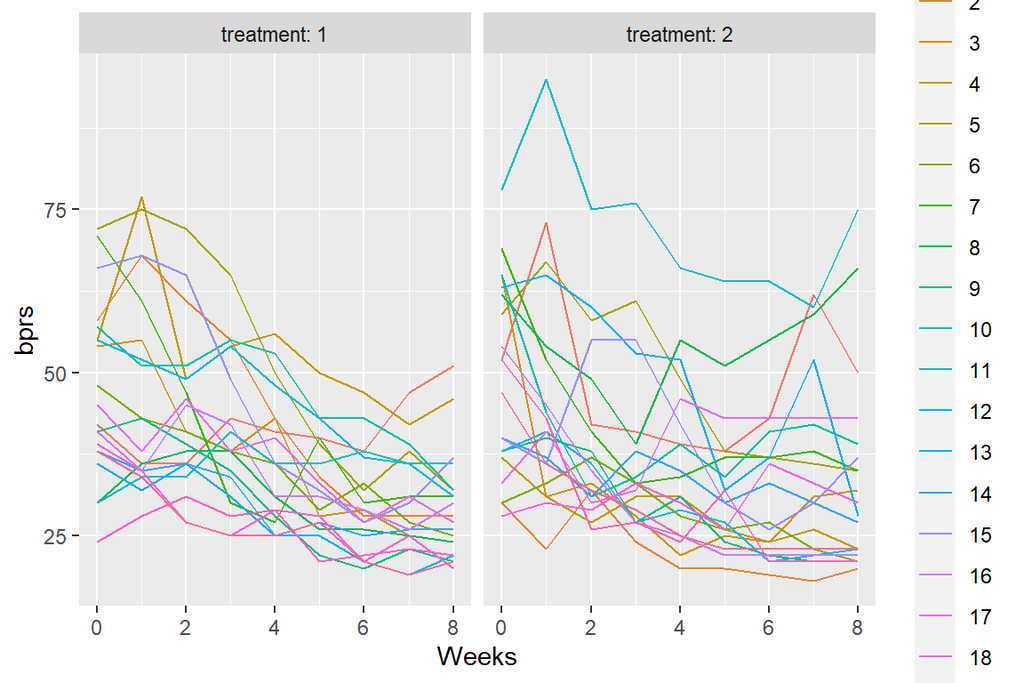

```r
# draw the plot of RATSL with the observed Weight values
ggplot(bprs_long, aes(x = week, y = bprs, col = subject)) +
  geom_line() +
  scale_x_continuous(name = "Weeks") +
  scale_y_continuous(name = "bprs") +
  scale_linetype_manual(values = rep(1:10, times=4)) +
  facet_grid(. ~ treatment, labeller = label_both)
```

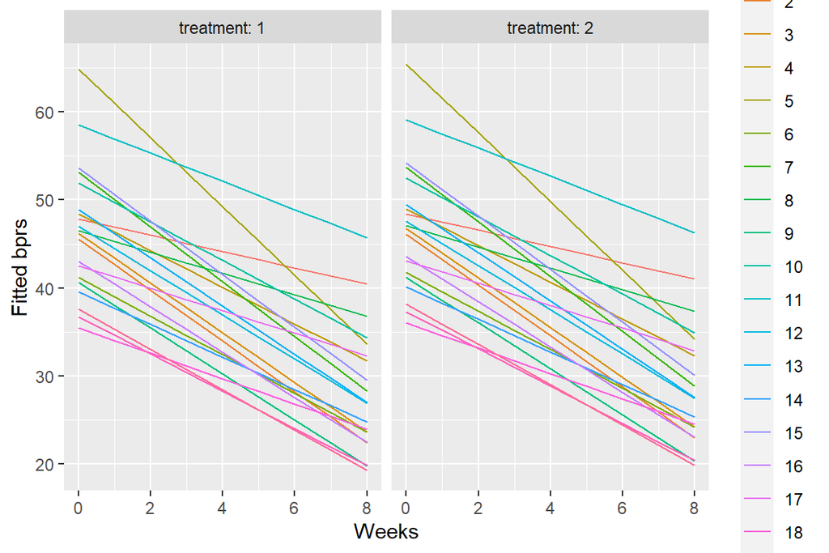

```r
# create a vector of the fitted values from the wanted model
Fitted <- fitted(int_slope_model)

# create a new column fitted to RATSL
bprs_long <- bprs_long %>% mutate(fitted = Fitted)

# draw the plot of RATSL with the Fitted values of weight
ggplot(bprs_long, aes(x = week, y = Fitted, col = subject)) +
  geom_line() +
  scale_x_continuous(name = "Weeks") +
  scale_y_continuous(name = "Fitted bprs")  +
  scale_linetype_manual(values = rep(1:10, times=4)) +
  facet_grid(. ~ treatment, labeller = label_both)
```

Looking at the model, it can be concluded that there is no tratment that worked better since the results for the both groups are having a similar pattern.  
——————–  
That`s all. Thank you for the course! It was enjoyable and interesting as I expected. The idea with GitHub and peer-review is brilliant :)